# Results

Working version

Williams, G. P.,

22<sup>nd</sup> July, 2020 (Last updated: 03<sup>th</sup> August, 2020)

```r
library(tidyverse)
library(here)
library(afex)
library(brms)
library(emmeans)
```

```r
data <- list()
r_file_list <- list.files(
  path = here::here("02_data", "02_cleaned", "02_aggregated", "01_rds"),
  pattern = "rds$",
  full.names = TRUE
)
data <- r_file_list %>%
  map(read_rds)
names(data) <- r_file_list %>%
  sub(".*/", "", .) %>%
  substr(., 1, nchar(.)-4)

data$demo <- read_rds(
  here("02_data", "02_cleaned", "01_multilevel", "01_rds", "demographics.rds")
)
data$games_played <- read_rds(
  here("02_data", "02_cleaned", "01_multilevel", "01_rds", "games_played_wider.rds")
)
```

# DAS data

```r
# das: subscale, hours played, time (before/after)
das_data <- left_join(
  data$das_longer,
  data$games_played %>% select(response_id, time, total_hours),
  by = c("response_id", "time")
)

# order time so before comes first
das_data$time <- factor(
  das_data$time,
  levels = c("before", "after")
  )

# set contrasts
das_data$time <- as.factor(das_data$time)
contrasts(das_data$time) <- contr.sum(2)
das_data$subscale <- as.factor(das_data$subscale)
contrasts(das_data$subscale) <- contr.sum(3)

# make id numeric
das_data$id <- as.numeric(factor(das_data$response_id))

# log transform predictor, accounting for 0
das_data$total_hours_log <- log(1 + das_data$total_hours)

# standarise predictor
das_data$total_hours_s <- (das_data$total_hours - mean(das_data$total_hours))/
  sd(das_data$total_hours)
```

## plots

### Untranformed hours, including all observations

[figure not shown]

```r
ggplot(das_data, aes(x = total_hours, y = score)) +
  facet_wrap(time ~ subscale) +
  geom_smooth(method = "lm", formula = "y ~ x") +
  geom_point(alpha = 0.1)
```

### Untranformed hours excluding observations of > 100 hours

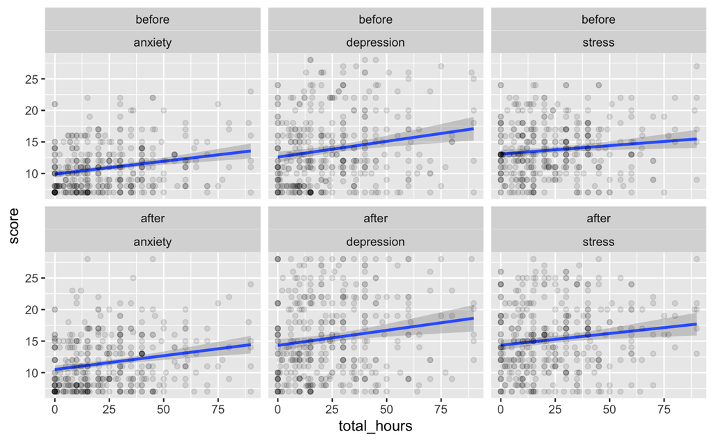

```r
ggplot(
  das_data %>% filter(total_hours < 100),
  aes(x = total_hours, y = score)
  ) +
  facet_wrap(time ~ subscale) +
  geom_smooth(method = "lm", formula = "y ~ x") +
  geom_point(alpha = 0.1)
```

## Analyse data

### Fit Model

Adapt model, with subscale and total hours nested within time.

Maybe model with spaghetti plots showing how people vary from averages.

```r
das_mod <- afex::mixed(
  score ~ time * subscale * total_hours_s + (1 | id),
  das_data,
  method = "S"
)
```

```
Contrasts set to contr.sum for the following variables: time, subscale
```

```
Fitting one lmer() model. [DONE]
Calculating p-values. [DONE]
```

```r
das_mod
```

```
Mixed Model Anova Table (Type 3 tests, S-method)

Model: score ~ time * subscale * total_hours_s + (1 | id)
Data: das_data
                       Effect         df          F p.value
1                        time 1, 2085.05 119.60 ***   <.001
2                    subscale 2, 2085.05 346.76 ***   <.001
3               total_hours_s 1, 2019.25     3.84 +    .050
4               time:subscale 2, 2085.05    6.59 **    .001
5          time:total_hours_s 1, 2085.05       2.61    .107
6      subscale:total_hours_s 2, 2085.05   8.36 ***   <.001
7 time:subscale:total_hours_s 2, 2085.05       1.40    .246
---
Signif. codes:  0 ‘***’ 0.001 ‘**’ 0.01 ‘*’ 0.05 ‘+’ 0.1 ‘ ’ 1
```

We have a main effect of time and subscale, an interaction between time and subscale, and an interaction between subscale and total hours played.

### Post-hoc tests

#### Time and Subscale Interaction

```
NOTE: Results may be misleading due to involvement in interactions
```

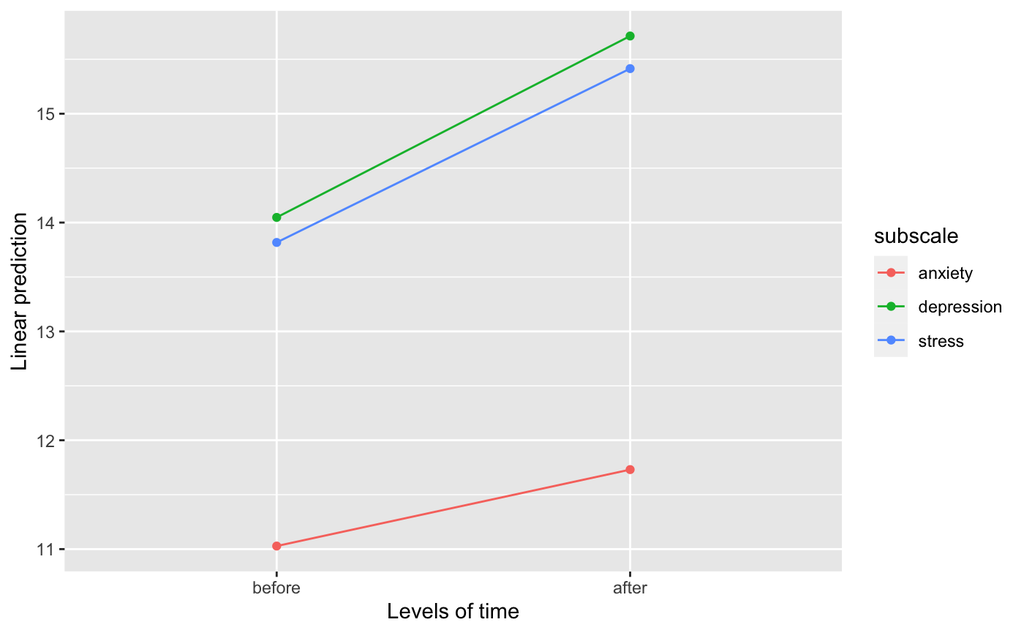

```r
emmip(das_mod, subscale ~ time)
```

```r
emmeans(das_mod, pairwise ~ time * subscale)
```

```
NOTE: Results may be misleading due to involvement in interactions
```

```
$emmeans
 time   subscale   emmean    SE  df lower.CL upper.CL
 before anxiety      11.0 0.332 272     10.4     11.7
 after  anxiety      11.7 0.332 272     11.1     12.4
 before depression   14.0 0.332 272     13.4     14.7
 after  depression   15.7 0.332 272     15.1     16.4
 before stress       13.8 0.332 272     13.2     14.5
 after  stress       15.4 0.332 272     14.8     16.1

Degrees-of-freedom method: kenward-roger
Confidence level used: 0.95

$contrasts
 contrast                             estimate    SE   df t.ratio p.value
 before,anxiety - after,anxiety         -0.702 0.209 2090  -3.355 0.0105
 before,anxiety - before,depression     -3.019 0.209 2090 -14.420 <.0001
 before,anxiety - after,depression      -4.686 0.209 2090 -22.379 <.0001
 before,anxiety - before,stress         -2.789 0.209 2090 -13.320 <.0001
 before,anxiety - after,stress          -4.386 0.209 2090 -20.948 <.0001
 after,anxiety - before,depression      -2.317 0.209 2090 -11.065 <.0001
 after,anxiety - after,depression       -3.983 0.209 2090 -19.024 <.0001
 after,anxiety - before,stress          -2.087 0.209 2090  -9.966 <.0001
 after,anxiety - after,stress           -3.684 0.209 2090 -17.594 <.0001
 before,depression - after,depression   -1.667 0.209 2090  -7.959 <.0001
 before,depression - before,stress       0.230 0.209 2090   1.099 0.8818
 before,depression - after,stress       -1.367 0.209 2090  -6.529 <.0001
 after,depression - before,stress        1.897 0.209 2090   9.058 <.0001
 after,depression - after,stress         0.299 0.209 2090   1.430 0.7085
 before,stress - after,stress           -1.597 0.209 2090  -7.628 <.0001

Degrees-of-freedom method: kenward-roger
P value adjustment: tukey method for comparing a family of 6 estimates
```

We see that anxiety is low in comparison to depression and stress before and after lockdown. For all subscales, scores increase after lockdown. Scores for depression and stress do not differ significantly before or after lockdown. All other differences are significant.

#### Subscale and Total Hours Played Interaction

```
NOTE: Results may be misleading due to involvement in interactions
```

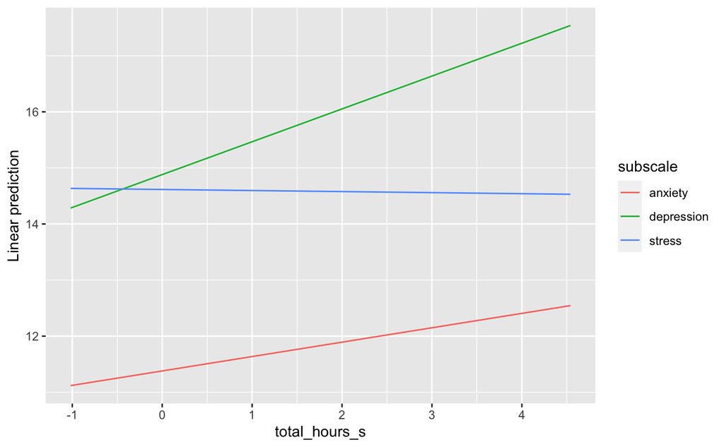

```r
emmip(das_mod, subscale ~ total_hours_s, cov.reduce = range)
```

```r
emtrends(das_mod, pairwise ~ subscale, var = "total_hours_s")
```

```
NOTE: Results may be misleading due to involvement in interactions
```

```
$emtrends
 subscale   total_hours_s.trend    SE   df lower.CL upper.CL
 anxiety                 0.2567 0.164 2211  -0.0656    0.579
 depression              0.5859 0.164 2211   0.2635    0.908
 stress                 -0.0189 0.164 2211  -0.3412    0.303

Results are averaged over the levels of: time
Degrees-of-freedom method: kenward-roger
Confidence level used: 0.95

$contrasts
 contrast             estimate    SE   df t.ratio p.value
 anxiety - depression   -0.329 0.148 2090 -2.223  0.0676
 anxiety - stress        0.276 0.148 2090  1.861  0.1504
 depression - stress     0.605 0.148 2090  4.084  0.0001

Results are averaged over the levels of: time
Degrees-of-freedom method: kenward-roger
P value adjustment: tukey method for comparing a family of 3 estimates
```

We see that neither stress nor anxiety change as the number of hours played increases. However, depression increases linearly as the number of hours played increases. The slopes differ significantly between depression and stress, but not between the other contrasts.

# DAS during quarantine only: using pre-quarantine DAS score as a predictor

```r
# das_data_quar <- pivot_wider(das_data, )
```

# Loneliness

We predict loneliness scores by total hours played in games and living situation (alone or other).

```r
# loneliness: hours played, time (before/after)
loneliness_data <- left_join(
  data$loneliness,
  data$games_played %>% select(response_id, total_hours),
  by = "response_id"
)
loneliness_data <- left_join(
  loneliness_data,
  data$demo %>% select(response_id, living_alone)
)
# order time so before comes first
loneliness_data$time <- factor(
  loneliness_data$time,
  levels = c("before", "after")
  )

# living alone: factor
loneliness_data$living_alone <- factor(
  loneliness_data$living_alone,
  levels = c(1, 0),
  labels = c("alone", "not_alone")
  )

# set contrasts
loneliness_data$time <- as.factor(loneliness_data$time)
contrasts(loneliness_data$time) <- contr.sum(2)

# make id numeric
loneliness_data$id <- as.numeric(factor(loneliness_data$response_id))

# log transform predictor, accounting for 0
loneliness_data$total_hours_log <- log(1 + loneliness_data$total_hours)

# standarise predictor
loneliness_data$total_hours_s <- (loneliness_data$total_hours - mean(loneliness_data$total_hours))/
  sd(loneliness_data$total_hours)

# fix the fact some aren't integers
loneliness_data$score <- round(loneliness_data$score, 0)



# NOTE: must explore why loneliness scores are sometimes floats.
```

## plots

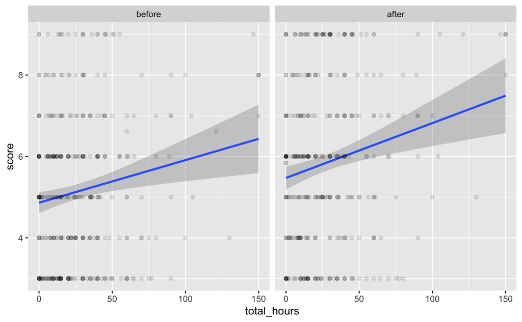

```r
ggplot(loneliness_data, aes(x = total_hours, y = score)) +
  facet_wrap(~time) +
  geom_smooth(method = "lm", formula = "y ~ x") +
  geom_point(alpha = 0.1)
```

```r
das_data %>%
  pivot_wider(names_from = "time", values_from = c("score", "total_hours")) %>%
  mutate(
    score_diff = score_before - score_after,
    hours_diff = total_hours_before - total_hours_after
  )
```

```r
xx <- loneliness_data %>%
  pivot_wider(names_from = "time", values_from = c("score", "total_hours")) %>%
  mutate(
    score_diff = score_before - score_after,
    hours_diff = total_hours_before - total_hours_after
  )

ggplot(xx, aes(x = hours_diff, y = score_diff)) +
  geom_smooth(method = "lm")
```

[output not shown]

diff in loneliness from hours played after lockdown.

look at difference in hours played and how that predicts after lockdown loneliness.

Clearly scores are ordinal here (Likert scale) and shouldn’t be treated as continuous.

```r
cores <- parallel::detectCores()

loneliness_mod <- brms::brm(
  score ~ time * total_hours * living_alone +
    (1 | id),
  data = loneliness_data,
  family = cumulative(),
  iter = 2000,
  chains = 4,
  cores = cores
  )
```

```
starting worker pid=1946 on localhost:11915 at 12:33:49.510
starting worker pid=1960 on localhost:11915 at 12:33:49.686
starting worker pid=1974 on localhost:11915 at 12:33:49.863
starting worker pid=1988 on localhost:11915 at 12:33:50.041
```

We can interrogate the parameter estimates directly here as the model is relatively simple in terms of the fixed effects.

```r
summary(loneliness_mod)
```

[output not shown]

# GAM: How do gaming habits mediate effects on the DAS/loneliness scales?

```r
# loneliness: hours played, time (before/after)
loneliness_data <- left_join(
  data$loneliness,
  data$games_played %>% select(response_id, time, total_hours),
  by = c("response_id", "time")
)
loneliness_data <- left_join(
  loneliness_data,
  data$demo %>% select(response_id, living_alone)
)

# order time so before comes first
loneliness_data$time <- factor(
  loneliness_data$time,
  levels = c("before", "after")
  )

# living alone: factor
loneliness_data$living_alone <- factor(
  loneliness_data$living_alone,
  levels = c(1, 0),
  labels = c("alone", "not_alone")
  )

# set contrasts
contrasts(loneliness_data$time) <- contr.sum(2)
contrasts(loneliness_data$living_alone) <- contr.sum(2)

# make id numeric
loneliness_data$id <- as.numeric(factor(loneliness_data$response_id))

# log transform predictor, accounting for 0
loneliness_data$total_hours_log <- log(1 + loneliness_data$total_hours)

# standarise predictor
loneliness_data$total_hours_s <- (loneliness_data$total_hours - mean(loneliness_data$total_hours))/
  sd(loneliness_data$total_hours)

# fix the fact some aren't integers
loneliness_data$score <- round(loneliness_data$score, 0)



# NOTE: must explore why loneliness scores are sometimes floats.
```